# Practical-Homework-2

Hamda Hassan

Due April 26, 2024

```r
library(tidyverse)
library(e1071)
library(ISLR2)
library(caret)
```

```r
library(ggplot2)
```

## LOAD DATA

Summary: The dataset was loaded directly from the public GitHub repository. It contains health, demographic, and behavioral variables used to predict diabetes.

```r
url <- "https://raw.githubusercontent.com/mendible/5322/main/Homework%202/nhis_2022.csv"
data <- read.csv(url)
```

## INITIAL DATA CHECK

Summary: Initial exploration was performed to understand the structure, variables, and distribution of the dataset. Additional checks were used to identify missing values and detect unrealistic or placeholder values (e.g., extreme values like 999), which helped guide the data cleaning process.

```r
str(data)
```

```
## 'data.frame':    35115 obs. of  48 variables:
##  $ YEAR       : int  2022 2022 2022 2022 2022 2022 2022 2022 2022 2022 ...
##  $ SERIAL     : int  1 2 2 3 4 4 5 6 7 8 ...
##  $ STRATA     : int  143 106 106 134 106 106 127 111 143 105 ...
##  $ PSU        : int  16 53 53 13 53 53 26 11 14 61 ...
##  $ NHISHID    : chr  "0002022H000001" "0002022H000003" "0002022H000003" "0002022H000006" ...
##  $ REGION     : int  4 3 3 2 3 3 2 4 4 1 ...
##  $ PERNUM     : int  1 1 2 1 1 2 1 1 1 1 ...
##  $ NHISPID    : chr  "0002022H00000110" "0002022H00000310" "0002022H00000320" "0002022H00000610" ...
##  $ HHX        : chr  "H000001" "H000003" "H000003" "H000006" ...
##  $ SAMPWEIGHT : num  8018 10117 7933 2681 10233 ...
##  $ ASTATFLG   : int  1 1 0 1 1 0 1 1 1 1 ...
##  $ CSTATFLG   : int  0 0 1 0 0 1 0 0 0 0 ...
##  $ AGE        : int  61 43 12 68 73 16 73 21 59 67 ...
##  $ SEX        : int  1 1 2 1 1 2 1 1 1 2 ...
```

[output cut: 34 more lines]

```r
colnames(data)
```

```
##  [1] "YEAR"        "SERIAL"      "STRATA"      "PSU"         "NHISHID"
##  [6] "REGION"      "PERNUM"      "NHISPID"     "HHX"         "SAMPWEIGHT"
## [11] "ASTATFLG"    "CSTATFLG"    "AGE"         "SEX"         "MARSTCUR"
## [16] "EDUC"        "HOURSWRK"    "POVERTY"     "HEIGHT"      "WEIGHT"
## [21] "BMICALC"     "HINOTCOVE"   "CANCEREV"    "CHEARTDIEV"  "DIABETICEV"
## [26] "HEARTATTEV"  "STROKEV"     "ALCANYNO"    "ALCDAYSYR"   "CIGDAYMO"
## [31] "MOD10DMIN"   "VIG10DMIN"   "FRUTNO"      "VEGENO"      "JUICEMNO"
## [36] "SALADSNO"    "BEANNO"      "SALSAMNO"    "TOMSAUCEMNO" "SODAPNO"
## [41] "FRIESPNO"    "SPORDRMNO"   "FRTDRINKMNO" "COFETEAMNO"  "POTATONO"
## [46] "PIZZANO"     "HRSLEEP"     "CVDSHT"
```

```r
head(data)
```

```
##   YEAR SERIAL STRATA PSU        NHISHID REGION PERNUM          NHISPID     HHX
## 1 2022      1    143  16 0002022H000001      4      1 0002022H00000110 H000001
## 2 2022      2    106  53 0002022H000003      3      1 0002022H00000310 H000003
## 3 2022      2    106  53 0002022H000003      3      2 0002022H00000320 H000003
## 4 2022      3    134  13 0002022H000006      2      1 0002022H00000610 H000006
## 5 2022      4    106  53 0002022H000007      3      1 0002022H00000710 H000007
## 6 2022      4    106  53 0002022H000007      3      2 0002022H00000720 H000007
##   SAMPWEIGHT ASTATFLG CSTATFLG AGE SEX MARSTCUR EDUC HOURSWRK POVERTY HEIGHT
## 1       8018        1        0  61   1        1  201       45      34     69
## 2      10117        1        0  43   1        1  301       45      37     70
## 3       7933        0        1  12   2        0    0        0      37     60
## 4       2681        1        0  68   1        5  505        0      31     75
## 5      10233        1        0  73   1        1  201        0      32     71
## 6       7712        0        1  16   2        0    0        0      32     65
##   WEIGHT BMICALC HINOTCOVE CANCEREV CHEARTDIEV DIABETICEV HEARTATTEV STROKEV
```

[output cut: 27 more lines]

```r
summary(data)
```

```
##       YEAR          SERIAL          STRATA           PSU
##  Min.   :2022   Min.   :    1   Min.   :100.0   Min.   :  1.00
##  1st Qu.:2022   1st Qu.: 7184   1st Qu.:112.0   1st Qu.:  8.00
##  Median :2022   Median :14403   Median :126.0   Median : 23.00
##  Mean   :2022   Mean   :14419   Mean   :125.8   Mean   : 30.94
##  3rd Qu.:2022   3rd Qu.:21648   3rd Qu.:140.0   3rd Qu.: 48.00
##  Max.   :2022   Max.   :28854   Max.   :151.0   Max.   :153.00
##    NHISHID              REGION          PERNUM        NHISPID
##  Length:35115       Min.   :1.000   Min.   :1.000   Length:35115
##  Class :character   1st Qu.:2.000   1st Qu.:1.000   Class :character
##  Mode  :character   Median :3.000   Median :1.000   Mode  :character
##                     Mean   :2.712   Mean   :1.178
##                     3rd Qu.:4.000   3rd Qu.:1.000
##                     Max.   :4.000   Max.   :2.000
##      HHX              SAMPWEIGHT       ASTATFLG         CSTATFLG
##  Length:35115       Min.   :  740   Min.   :0.0000   Min.   :0.0000
##  Class :character   1st Qu.: 5095   1st Qu.:1.0000   1st Qu.:0.0000
##  Mode  :character   Median : 7947   Median :1.0000   Median :0.0000
##                     Mean   : 9343   Mean   :0.7874   Mean   :0.2126
##                     3rd Qu.:11777   3rd Qu.:1.0000   3rd Qu.:0.0000
##                     Max.   :43112   Max.   :1.0000   Max.   :1.0000
##       AGE             SEX           MARSTCUR          EDUC
##  Min.   :  0.0   Min.   :1.000   Min.   :0.000   Min.   :  0.0
##  1st Qu.: 23.0   1st Qu.:1.000   1st Qu.:1.000   1st Qu.:103.0
##  Median : 45.0   Median :2.000   Median :1.000   Median :301.0
##  Mean   : 45.3   Mean   :1.532   Mean   :3.349   Mean   :248.4
##  3rd Qu.: 65.0   3rd Qu.:2.000   3rd Qu.:6.000   3rd Qu.:400.0
##  Max.   :999.0   Max.   :9.000   Max.   :9.000   Max.   :999.0
##     HOURSWRK        POVERTY          HEIGHT          WEIGHT
##  Min.   : 0.00   Min.   :11.00   Min.   : 0.00   Min.   :  0.0
##  1st Qu.: 0.00   1st Qu.:24.00   1st Qu.:62.00   1st Qu.:130.0
##  Median : 0.00   Median :33.00   Median :66.00   Median :165.0
##  Mean   :17.64   Mean   :30.28   Mean   :60.72   Mean   :215.2
##  3rd Qu.:40.00   3rd Qu.:37.00   3rd Qu.:70.00   3rd Qu.:203.0
##  Max.   :99.00   Max.   :37.00   Max.   :99.00   Max.   :999.0
##     BMICALC        HINOTCOVE        CANCEREV       CHEARTDIEV
##  Min.   : 11.5   Min.   :1.000   Min.   :0.000   Min.   :0.0000
##  1st Qu.: 24.0   1st Qu.:1.000   1st Qu.:1.000   1st Qu.:1.0000
##  Median : 28.3   Median :1.000   Median :1.000   Median :1.0000
##  Mean   :215.8   Mean   :1.093   Mean   :0.892   Mean   :0.8533
```

[output cut: 29 more lines]

```
##  Max.   :999.0   Max.   :999.0   Max.   :999.0   Max.   :999.0
##    SPORDRMNO      FRTDRINKMNO      COFETEAMNO       POTATONO
##  Min.   :  0.0   Min.   :  0.0   Min.   :  0.0   Min.   :  0.0
##  1st Qu.:  0.0   1st Qu.:  0.0   1st Qu.:  0.0   1st Qu.:  1.0
##  Median :  0.0   Median :  0.0   Median :  1.0   Median :  2.0
##  Mean   :242.3   Mean   :242.5   Mean   :243.2   Mean   :245.7
##  3rd Qu.: 15.0   3rd Qu.: 10.0   3rd Qu.: 30.0   3rd Qu.: 20.0
##  Max.   :999.0   Max.   :999.0   Max.   :999.0   Max.   :999.0
##     PIZZANO         HRSLEEP           CVDSHT
##  Min.   :  0.0   Min.   : 0.000   Min.   :0.000
##  1st Qu.:  1.0   1st Qu.: 5.000   1st Qu.:1.000
##  Median :  2.0   Median : 7.000   Median :2.000
##  Mean   :244.8   Mean   : 8.135   Mean   :1.791
##  3rd Qu.: 10.0   3rd Qu.: 8.000   3rd Qu.:2.000
##  Max.   :999.0   Max.   :99.000   Max.   :9.000
```

```r
table(data$DIABETICEV)
```

```
##
##     1     2     7     9
## 32102  2975    27    11
```

```r
# Count missing values in each column
colSums(is.na(data))
```

```
##        YEAR      SERIAL      STRATA         PSU     NHISHID      REGION
##           0           0           0           0           0           0
##      PERNUM     NHISPID         HHX  SAMPWEIGHT    ASTATFLG    CSTATFLG
##           0           0           0           0           0           0
##         AGE         SEX    MARSTCUR        EDUC    HOURSWRK     POVERTY
##           0           0           0           0           0           0
##      HEIGHT      WEIGHT     BMICALC   HINOTCOVE    CANCEREV  CHEARTDIEV
##           0           0           0           0           0           0
##  DIABETICEV  HEARTATTEV     STROKEV    ALCANYNO   ALCDAYSYR    CIGDAYMO
##           0           0           0           0           0           0
##   MOD10DMIN   VIG10DMIN      FRUTNO      VEGENO    JUICEMNO    SALADSNO
##           0           0           0           0           0           0
##      BEANNO    SALSAMNO TOMSAUCEMNO     SODAPNO    FRIESPNO   SPORDRMNO
##           0           0           0           0           0           0
## FRTDRINKMNO  COFETEAMNO    POTATONO     PIZZANO     HRSLEEP      CVDSHT
##           0           0           0           0           0           0
```

```r
# Check suspicious high values
summary(data$AGE)
```

```
##    Min. 1st Qu.  Median    Mean 3rd Qu.    Max.
##     0.0    23.0    45.0    45.3    65.0   999.0
```

```r
summary(data$BMICALC)
```

```
##    Min. 1st Qu.  Median    Mean 3rd Qu.    Max.
##    11.5    24.0    28.3   215.8    36.8   996.0
```

```r
summary(data$MOD10DMIN)
```

```
##    Min. 1st Qu.  Median    Mean 3rd Qu.    Max.
##     0.0     0.0    20.0    34.6    45.0   999.0
```

```r
summary(data$SODAPNO)
```

```
##    Min. 1st Qu.  Median    Mean 3rd Qu.    Max.
##     0.0     0.0     1.0   243.1    30.0   999.0
```

Summary: Histograms were used to visualize the distribution of key variables. This helped identify skewness, outliers, and unrealistic values that needed to be addressed during cleaning.

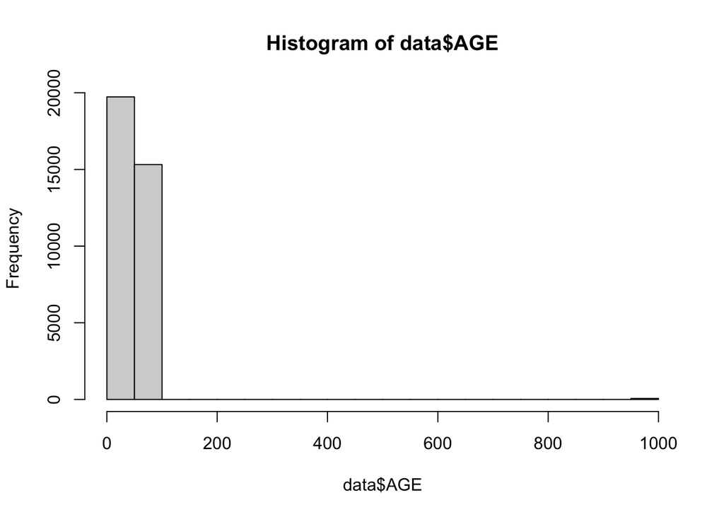

```r
hist(data$AGE)
```

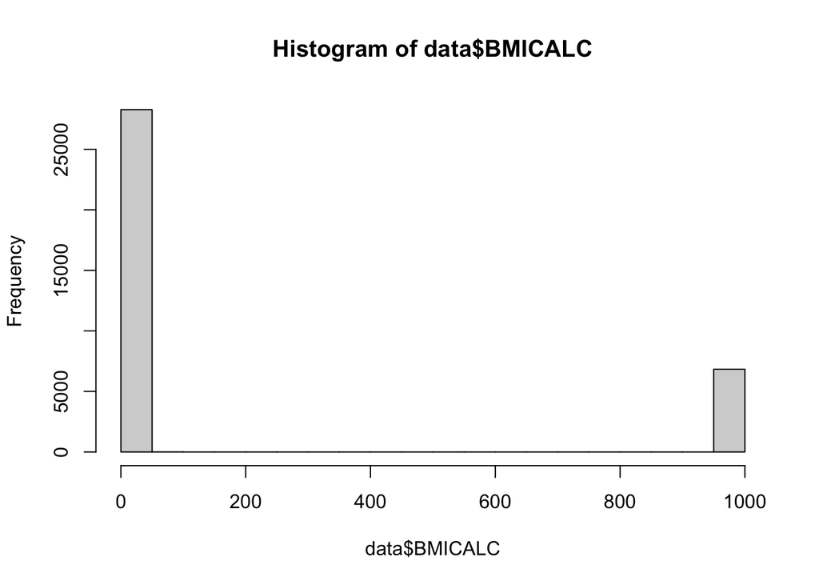

```r
hist(data$BMICALC)
```

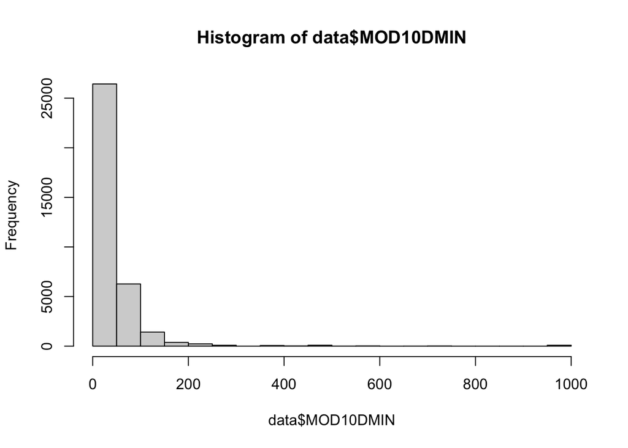

```r
hist(data$MOD10DMIN)
```

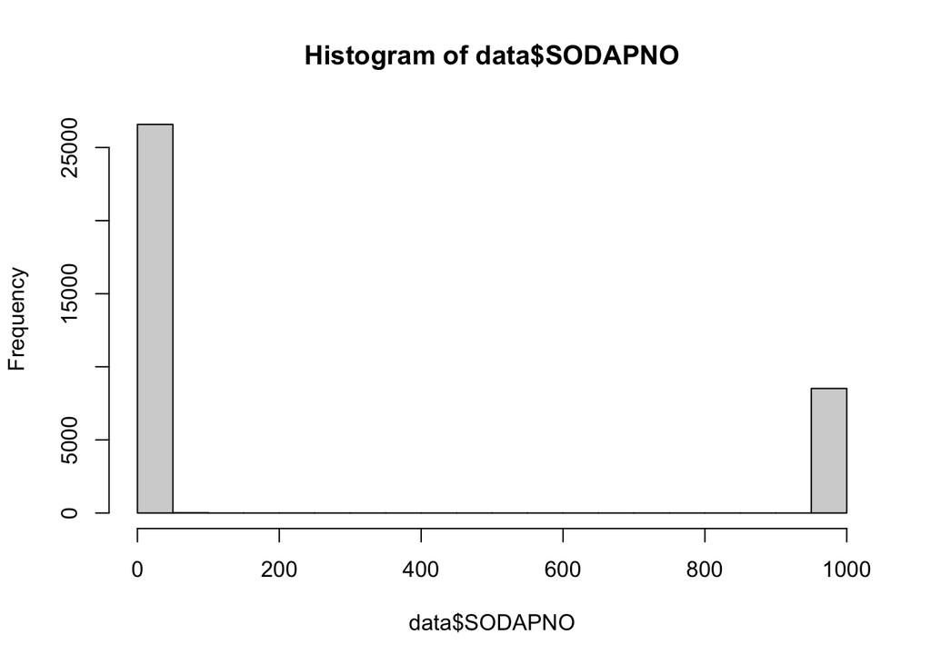

```r
hist(data$SODAPNO)
```

Summary: Simple checks were used to compare average values of key variables across diabetes groups. This gave an early sense of potential relationships in the data.

```r
aggregate(AGE ~ DIABETICEV, data = data, mean, na.rm = TRUE)
```

```
##   DIABETICEV       AGE
## 1          1  43.34334
## 2          2  65.36437
## 3          7 155.59259
## 4          9  51.90909
```

```r
aggregate(BMICALC ~ DIABETICEV, data = data, mean, na.rm = TRUE)
```

```
##   DIABETICEV  BMICALC
## 1          1 222.4145
## 2          2 142.3330
## 3          7 422.8926
## 4          9 205.0818
```

## TARGET VARIABLE

Summary: The target variable was created by recoding DIABETICEV into a binary outcome (1 = diabetes, 0 = no diabetes). Unclear responses were treated as missing, and the variable was converted to a factor for classification.

```r
data <- data %>%
  mutate(
    diabetes = case_when(
      DIABETICEV == 2 ~ 1,  # YES = 1
      DIABETICEV == 1 ~ 0,  # NO = 0
      TRUE ~ NA_real_
    ),
    diabetes = as.factor(diabetes)
  )
```

## CLEANING + Build Model

Summmary: The data was cleaned by removing invalid placeholder values and restricting the sample to adults (18+). A subset of relevant predictors was selected, extreme soda values were capped, categorical variables were formatted, and missing observations were removed to create the final modeling dataset.

```r
model_data <- data %>%
  filter(AGE >= 18) %>%
  select(diabetes, AGE, SEX, BMICALC, MOD10DMIN, SODAPNO) %>%
  mutate(across(
    -diabetes,
    ~ifelse(. %in% c(7,8,9,96,97,98,99,996,997,998,999), NA, .)
  )) %>%
  mutate(
    SODAPNO = ifelse(SODAPNO > 30, 30, SODAPNO),
    SEX = factor(SEX, levels = c(1, 2),
                 labels = c("Male", "Female"))
  ) %>%
  drop_na()
```

## CHECKING FOR MISTAKES

Summary: These checks were used to confirm that the cleaned dataset looked reasonable before modeling. I checked the final variable summaries, diabetes class balance, and sex distribution to make sure there were no obvious cleaning issues left.

```r
summary(model_data)
```

```
##  diabetes       AGE           SEX           BMICALC        MOD10DMIN
##  0:21300   Min.   :18.0   Male  :10910   Min.   :14.80   Min.   :  0.00
##  1: 2477   1st Qu.:37.0   Female:12867   1st Qu.:23.80   1st Qu.:  0.00
##            Median :55.0                  Median :27.20   Median : 30.00
##            Mean   :53.2                  Mean   :27.95   Mean   : 42.94
##            3rd Qu.:68.0                  3rd Qu.:31.20   3rd Qu.: 60.00
##            Max.   :85.0                  Max.   :52.70   Max.   :720.00
##     SODAPNO
##  Min.   : 0.000
##  1st Qu.: 0.000
##  Median : 0.000
##  Mean   : 1.653
##  3rd Qu.: 2.000
##  Max.   :30.000
```

```r
table(model_data$diabetes)
```

```
##
##     0     1
## 21300  2477
```

```r
table(model_data$SEX)
```

```
##
##   Male Female
##  10910  12867
```

## TRAIN / TEST SPLIT FIRST

Summary: The cleaned dataset was split into training and testing sets, with 80% used for training and 20% held out for evaluation. A random seed was set so the results could be reproduced.

```r
set.seed(123)

train_index <- sample(1:nrow(model_data), size = 0.8 * nrow(model_data))

train_raw <- model_data[train_index, ]
test_raw  <- model_data[-train_index, ]
```

## DUMMY VARIABLES + SCALE AFTER SPLIT

Summary: Categorical variables were converted into dummy variables, and all predictors were scaled to ensure the SVM models performed correctly. These steps were applied after the train/test split to prevent data leakage.

```r
# Convert predictors only into dummy variables
dummies <- dummyVars(~ ., data = train_raw[, -1])

train_matrix <- predict(dummies, newdata = train_raw[, -1])
test_matrix  <- predict(dummies, newdata = test_raw[, -1])

# Scale numeric predictors after dummy encoding
preproc <- preProcess(train_matrix, method = c("center", "scale"))

train_scaled <- predict(preproc, train_matrix)
test_scaled  <- predict(preproc, test_matrix)

train <- data.frame(diabetes = train_raw$diabetes, train_scaled)
test  <- data.frame(diabetes = test_raw$diabetes, test_scaled)

# Reattach response variable and ensure it is a factor
train$diabetes <- factor(train$diabetes, levels = c("0", "1"))
test$diabetes  <- factor(test$diabetes, levels = c("0", "1"))
```

## Tests

Summary: Final checks were performed to confirm that the training and testing datasets were properly structured, had consistent factor levels, and contained no missing values.

```r
str(train)
```

```
## 'data.frame':    19021 obs. of  7 variables:
##  $ diabetes  : Factor w/ 2 levels "0","1": 1 1 1 1 1 1 1 1 1 1 ...
##  $ AGE       : num  -1.15 0.103 0.321 0.756 -1.749 ...
##  $ SEX.Male  : num  -0.924 -0.924 1.083 1.083 -0.924 ...
##  $ SEX.Female: num  0.924 0.924 -1.083 -1.083 0.924 ...
##  $ BMICALC   : num  -0.2403 1.7456 -0.0778 1.6914 0.5541 ...
##  $ MOD10DMIN : num  -0.7363 -0.4776 -0.2188 4.439 -0.0463 ...
##  $ SODAPNO   : num  0.0784 -0.4032 -0.4032 -0.4032 -0.1624 ...
```

```r
str(test)
```

```
## 'data.frame':    4756 obs. of  7 variables:
##  $ diabetes  : Factor w/ 2 levels "0","1": 1 1 1 1 1 1 1 1 1 2 ...
##  $ AGE       : num  -1.7487 0.7562 0.3206 -0.2784 -0.0606 ...
##  $ SEX.Male  : num  1.083 -0.924 1.083 -0.924 1.083 ...
##  $ SEX.Female: num  -1.083 0.924 -1.083 0.924 -1.083 ...
##  $ BMICALC   : num  0.446 0.355 -1.089 0.59 0.987 ...
##  $ MOD10DMIN : num  0.04 1.334 0.299 -0.736 -0.219 ...
##  $ SODAPNO   : num  0.0784 -0.4032 -0.4032 0.0784 0.3191 ...
```

```r
levels(train$diabetes)
```

```
## [1] "0" "1"
```

```r
levels(test$diabetes)
```

```
## [1] "0" "1"
```

```r
anyNA(train)
```

```
## [1] FALSE
```

```r
anyNA(test)
```

```
## [1] FALSE
```

## CLASS WEIGHTS (IMPORTANT)

Summary: Class weights were applied to address the imbalance in the dataset, where far fewer individuals have diabetes. Higher weight was given to the diabetes class to improve the model’s ability to correctly detect positive cases.

```r
class_counts <- table(train$diabetes)

class_weights <- c(
  "0" = 1,
  "1" = as.numeric(class_counts["0"] / class_counts["1"])
)

print(class_counts)
```

```
##
##     0     1
## 17066  1955
```

```r
print(class_weights)
```

```
##        0        1
## 1.000000 8.729412
```

## BASE MODELS

Summary: Three SVM models (radial, polynomial, and linear) were trained using the weighted dataset. Each model was evaluated on the test set using accuracy, sensitivity, and specificity to compare performance across different kernel types.

Linear

```r
svm_linear <- svm(
  diabetes ~ .,
  data = train,
  kernel = "linear",
  cost = 1,
  class.weights = class_weights
)

pred_linear_base <- predict(svm_linear, test)
cm_linear_base <- confusionMatrix(pred_linear_base, test$diabetes, positive = "1")
cm_linear_base
```

```
## Confusion Matrix and Statistics
##
##           Reference
## Prediction    0    1
##          0 2629  111
##          1 1605  411
##
##                Accuracy : 0.6392
##                  95% CI : (0.6254, 0.6529)
##     No Information Rate : 0.8902
##     P-Value [Acc > NIR] : 1
##
##                   Kappa : 0.1811
##
##  Mcnemar's Test P-Value : <2e-16
##
##             Sensitivity : 0.78736
##             Specificity : 0.62093
##          Pos Pred Value : 0.20387
##          Neg Pred Value : 0.95949
##              Prevalence : 0.10976
##          Detection Rate : 0.08642
##    Detection Prevalence : 0.42389
##       Balanced Accuracy : 0.70414
##
##        'Positive' Class : 1
##
```

Radial

```r
svm_radial <- svm(
  diabetes ~ .,
  data = train,
  kernel = "radial",
  cost = 1,
  gamma = 0.05,
  class.weights = class_weights
)

pred_radial_base <- predict(svm_radial, test)
cm_radial_base <- confusionMatrix(pred_radial_base, test$diabetes, positive = "1")
cm_radial_base
```

```
## Confusion Matrix and Statistics
##
##           Reference
## Prediction    0    1
##          0 2538   92
##          1 1696  430
##
##                Accuracy : 0.6241
##                  95% CI : (0.6101, 0.6378)
##     No Information Rate : 0.8902
##     P-Value [Acc > NIR] : 1
##
##                   Kappa : 0.1803
##
##  Mcnemar's Test P-Value : <2e-16
##
##             Sensitivity : 0.82375
##             Specificity : 0.59943
##          Pos Pred Value : 0.20226
##          Neg Pred Value : 0.96502
##              Prevalence : 0.10976
##          Detection Rate : 0.09041
##    Detection Prevalence : 0.44701
##       Balanced Accuracy : 0.71159
##
##        'Positive' Class : 1
##
```

Polynomial

```r
set.seed(123)
train_small <- train[sample(1:nrow(train), min(5000, nrow(train))), ]

svm_poly <- svm(
  diabetes ~ .,
  data = train_small,
  kernel = "polynomial",
  degree = 2,
  cost = 1,
  class.weights = class_weights
)

pred_poly_base <- predict(svm_poly, test)
cm_poly_base <- confusionMatrix(pred_poly_base, test$diabetes, positive = "1")
cm_poly_base
```

```
## Confusion Matrix and Statistics
##
##           Reference
## Prediction    0    1
##          0 2201  204
##          1 2033  318
##
##                Accuracy : 0.5296
##                  95% CI : (0.5153, 0.5439)
##     No Information Rate : 0.8902
##     P-Value [Acc > NIR] : 1
##
##                   Kappa : 0.0509
##
##  Mcnemar's Test P-Value : <2e-16
##
##             Sensitivity : 0.60920
##             Specificity : 0.51984
##          Pos Pred Value : 0.13526
##          Neg Pred Value : 0.91518
##              Prevalence : 0.10976
##          Detection Rate : 0.06686
##    Detection Prevalence : 0.49432
##       Balanced Accuracy : 0.56452
##
##        'Positive' Class : 1
##
```

## TUNING

Summary: The radial SVM was tuned using cross-validation to find the best combination of cost and gamma values. Multiple parameter values were tested, and the model with the best performance on validation data was selected and evaluated on the test set.

```r
tuned_radial <- tune(
  svm,
  diabetes ~ .,
  data = train,
  kernel = "radial",
  ranges = list(
    cost = c(0.5, 1, 2, 5),
    gamma = c(0.01, 0.05, 0.1)
  ),
  tunecontrol = tune.control(cross = 3),
  class.weights = class_weights
)

best_radial <- tuned_radial$best.model

pred_radial <- predict(best_radial, test)
cm_radial_tuned <- confusionMatrix(pred_radial, test$diabetes, positive = "1")
cm_radial_tuned
```

```
## Confusion Matrix and Statistics
##
##           Reference
## Prediction    0    1
##          0 2579   94
##          1 1655  428
##
##                Accuracy : 0.6323
##                  95% CI : (0.6184, 0.646)
##     No Information Rate : 0.8902
##     P-Value [Acc > NIR] : 1
##
##                   Kappa : 0.1857
##
##  Mcnemar's Test P-Value : <2e-16
##
##             Sensitivity : 0.81992
##             Specificity : 0.60912
##          Pos Pred Value : 0.20547
##          Neg Pred Value : 0.96483
##              Prevalence : 0.10976
##          Detection Rate : 0.08999
##    Detection Prevalence : 0.43797
##       Balanced Accuracy : 0.71452
##
##        'Positive' Class : 1
##
```

## MODEL COMPARISON

Summary: Model performance was summarized in a comparison table using accuracy, sensitivity, and specificity. This allowed for a clear comparison across all SVM kernels, including the tuned radial model.

```r
results <- data.frame(
  Model = c("Linear", "Radial", "Polynomial", "Radial (Tuned)"),
  Accuracy = c(
    cm_linear_base$overall["Accuracy"],
    cm_radial_base$overall["Accuracy"],
    cm_poly_base$overall["Accuracy"],
    cm_radial_tuned$overall["Accuracy"]
  ),
  Sensitivity = c(
    cm_linear_base$byClass["Sensitivity"],
    cm_radial_base$byClass["Sensitivity"],
    cm_poly_base$byClass["Sensitivity"],
    cm_radial_tuned$byClass["Sensitivity"]
  ),
  Specificity = c(
    cm_linear_base$byClass["Specificity"],
    cm_radial_base$byClass["Specificity"],
    cm_poly_base$byClass["Specificity"],
    cm_radial_tuned$byClass["Specificity"]
  )
)

results
```

```
##            Model  Accuracy Sensitivity Specificity
## 1         Linear 0.6391926   0.7873563   0.6209258
## 2         Radial 0.6240538   0.8237548   0.5994332
## 3     Polynomial 0.5296468   0.6091954   0.5198394
## 4 Radial (Tuned) 0.6322540   0.8199234   0.6091167
```

## SVM DECISION BOUNDARY PLOT

Summary: A two-variable SVM decision boundary was visualized using BMI and physical activity to illustrate how the model separates classes. The plot shows that these variables alone do not clearly separate diabetes cases, highlighting the need for more complex models.

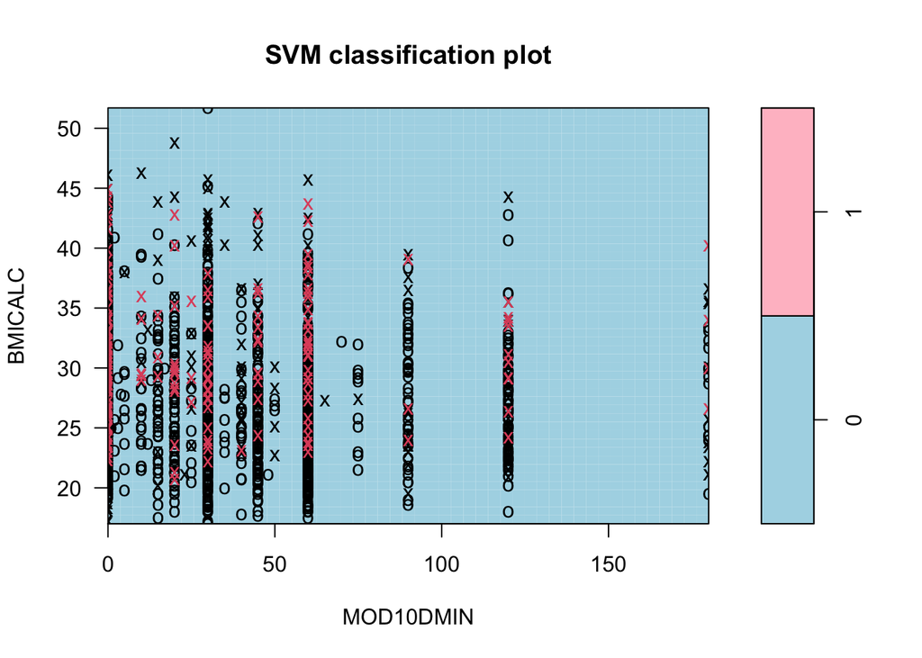

```r
set.seed(123)

plot_data <- model_data %>%
  select(diabetes, BMICALC, MOD10DMIN) %>%
  filter(MOD10DMIN <= 200) %>%   # key fix
  sample_n(2000)

# Train SVM
svm_2d <- svm(
  diabetes ~ BMICALC + MOD10DMIN,
  data = plot_data,
  kernel = "radial",
  cost = 1,
  gamma = 0.05
)

# Plot
plot(
  svm_2d, plot_data,
  main = "SVM Decision Boundary (BMI vs Physical Activity)",
  xlab = "BMI",
  ylab = "Moderate Activity (Minutes)",
  col = c("lightblue", "pink")
)
```

## BMI vs Diabetes

Summary: A boxplot of BMI by diabetes status shows a clear upward shift for individuals with diabetes, indicating that BMI is a strong predictor.

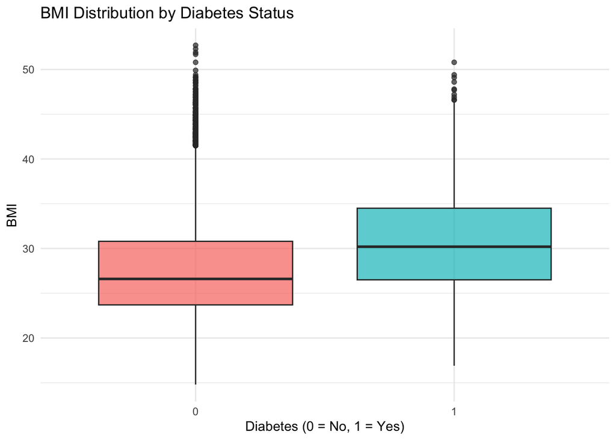

```r
ggplot(model_data, aes(x = diabetes, y = BMICALC, fill = diabetes)) +
  geom_boxplot(alpha = 0.7) +
  labs(
    title = "BMI Distribution by Diabetes Status",
    x = "Diabetes (0 = No, 1 = Yes)",
    y = "BMI"
  ) +
  theme_minimal() +
  theme(legend.position = "none")
```

## Physical Activity vs Diabetes

Summary: A boxplot of physical activity shows significant overlap between groups, suggesting it is a weaker predictor when considered on its own.

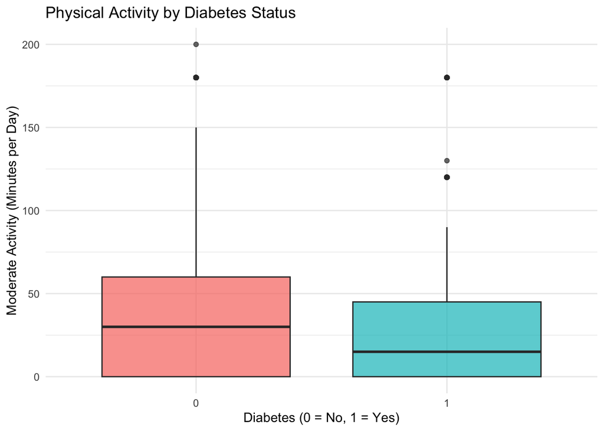

```r
ggplot(model_data, aes(x = diabetes, y = MOD10DMIN, fill = diabetes)) +
  geom_boxplot(alpha = 0.7) +
  coord_cartesian(ylim = c(0, 200)) +
  labs(
    title = "Physical Activity by Diabetes Status",
    x = "Diabetes (0 = No, 1 = Yes)",
    y = "Moderate Activity (Minutes per Day)"
  ) +
  theme_minimal() +
  theme(legend.position = "none")
```